# Beschrijvende statistiek

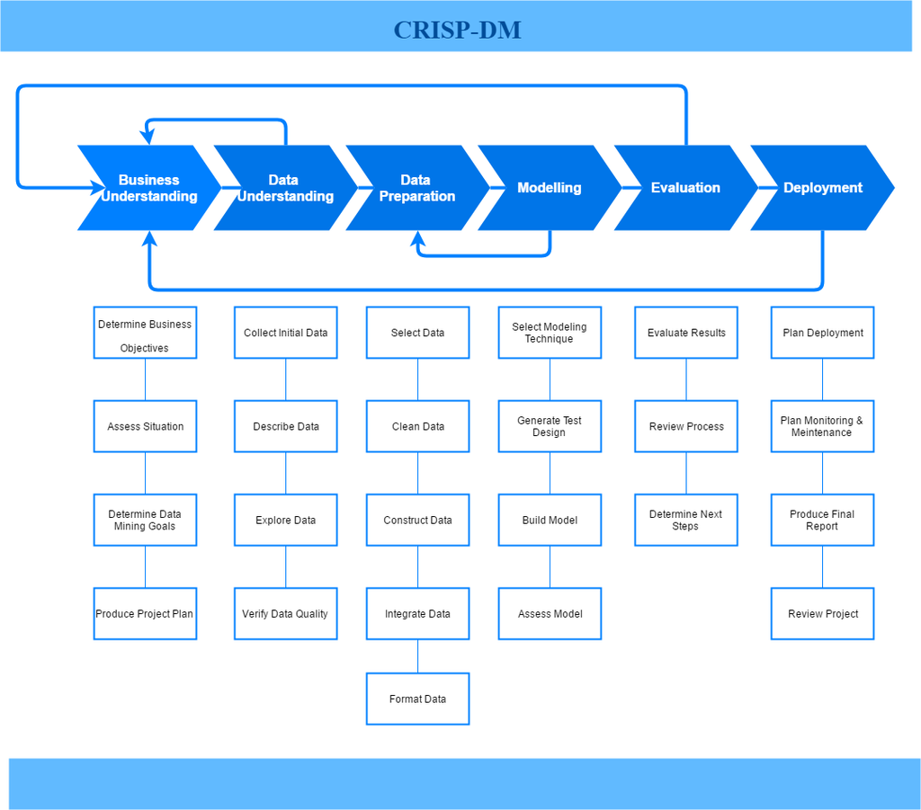

# Data inlezen

We gaan een *comma separated variables (csv)* bestand inlezen. De dataset komt uit de tweejaarlijkse [europese sociale survey (css)](http://www.europeansocialsurvey.org/).

Nadat we de ruwe data hebben ingelezen, kunnen we de kwaliteit beoordelen.

```r
ruweData <- read.csv("ess.csv")
dim(ruweData)
```

```
[1] 2364  566
```

```r
head(ruweData[1:15])
```

|  | name | essround | edition | proddate | cntry | idno | tvtot | tvpol | rdtot | rdpol | nwsptot | nwsppol | netuse | ppltrst | pplfair |
| --- | --- | --- | --- | --- | --- | --- | --- | --- | --- | --- | --- | --- | --- | --- | --- |
| 1 | ESS1e06_5 | 1 | 6.5 | 01.12.2016 | NL | 1000071 | 6 | 4 | 0 | NA | 5 | 2 | 1 | 10 | 10 |
| 2 | ESS1e06_5 | 1 | 6.5 | 01.12.2016 | NL | 1000081 | 7 | 5 | 0 | NA | 2 | 1 | 0 | 8 | 4 |
| 3 | ESS1e06_5 | 1 | 6.5 | 01.12.2016 | NL | 1000101 | 3 | 2 | 7 | 7 | 3 | 2 | 6 | 8 | 8 |
| 4 | ESS1e06_5 | 1 | 6.5 | 01.12.2016 | NL | 1000111 | 3 | 2 | 0 | NA | 1 | 1 | 6 | 8 | 2 |
| 5 | ESS1e06_5 | 1 | 6.5 | 01.12.2016 | NL | 1000131 | 4 | 4 | 7 | 5 | 3 | 2 | 0 | 5 | 6 |
| 6 | ESS1e06_5 | 1 | 6.5 | 01.12.2016 | NL | 1000261 | 3 | 2 | 7 | 2 | 1 | 0 | 7 | 6 | 7 |

```r
str(ruweData[1:15])
```

```
'data.frame':   2364 obs. of  15 variables:
 $ name    : Factor w/ 1 level "ESS1e06_5": 1 1 1 1 1 1 1 1 1 1 ...
 $ essround: int  1 1 1 1 1 1 1 1 1 1 ...
 $ edition : num  6.5 6.5 6.5 6.5 6.5 6.5 6.5 6.5 6.5 6.5 ...
 $ proddate: Factor w/ 1 level "01.12.2016": 1 1 1 1 1 1 1 1 1 1 ...
 $ cntry   : Factor w/ 1 level "NL": 1 1 1 1 1 1 1 1 1 1 ...
 $ idno    : int  1000071 1000081 1000101 1000111 1000131 1000261 1000271 1000291 1000361 1000381 ...
 $ tvtot   : int  6 7 3 3 4 3 5 2 4 5 ...
 $ tvpol   : int  4 5 2 2 4 2 5 1 2 2 ...
 $ rdtot   : int  0 0 7 0 7 7 0 0 0 0 ...
 $ rdpol   : int  NA NA 7 NA 5 2 NA NA NA NA ...
 $ nwsptot : int  5 2 3 1 3 1 0 5 1 2 ...
 $ nwsppol : int  2 1 2 1 2 0 NA 3 1 2 ...
 $ netuse  : int  1 0 6 6 0 7 7 2 7 1 ...
 $ ppltrst : int  10 8 8 8 5 6 5 3 6 4 ...
 $ pplfair : int  10 4 8 2 6 7 7 3 5 8 ...
```

```r
summary(ruweData[1:15])
```

```
        name         essround    edition          proddate    cntry          idno
 ESS1e06_5:2364   Min.   :1   Min.   :6.5   01.12.2016:2364   NL:2364   Min.   :1000071
                  1st Qu.:1   1st Qu.:6.5                               1st Qu.:1009848
                  Median :1   Median :6.5                               Median :1018806
                  Mean   :1   Mean   :6.5                               Mean   :1018702
                  3rd Qu.:1   3rd Qu.:6.5                               3rd Qu.:1027984
                  Max.   :1   Max.   :6.5                               Max.   :1036001

     tvtot           tvpol           rdtot           rdpol          nwsptot
 Min.   :0.000   Min.   :0.000   Min.   :0.000   Min.   :0.000   Min.   :0.000
 1st Qu.:3.000   1st Qu.:2.000   1st Qu.:1.000   1st Qu.:1.000   1st Qu.:1.000
 Median :5.000   Median :2.000   Median :2.000   Median :1.000   Median :2.000
 Mean   :4.634   Mean   :2.335   Mean   :3.346   Mean   :1.687   Mean   :1.645
 3rd Qu.:6.000   3rd Qu.:3.000   3rd Qu.:7.000   3rd Qu.:2.000   3rd Qu.:2.000
 Max.   :7.000   Max.   :7.000   Max.   :7.000   Max.   :7.000   Max.   :7.000
 NA's   :3       NA's   :53      NA's   :3       NA's   :451     NA's   :3
    nwsppol          netuse         ppltrst          pplfair
 Min.   :0.000   Min.   :0.000   Min.   : 0.000   Min.   : 0.000
 1st Qu.:1.000   1st Qu.:0.000   1st Qu.: 5.000   1st Qu.: 5.000
 Median :1.000   Median :4.000   Median : 6.000   Median : 7.000
 Mean   :1.325   Mean   :3.342   Mean   : 5.708   Mean   : 6.177
 3rd Qu.:2.000   3rd Qu.:6.000   3rd Qu.: 7.000   3rd Qu.: 7.000
 Max.   :7.000   Max.   :7.000   Max.   :10.000   Max.   :10.000
 NA's   :483     NA's   :2       NA's   :1        NA's   :9
```

De set bestaat uit 2364 rijen (observaties) en 566 kolommen (variabelen). Gezien de omvang van het aantal variabelen beperken we ons even tot de eerste 15 kolommen. Deze bestaan uit verschillende datatypes: numerieke (`num` en `int`) en categorische (`Factor`).

# Kwaliteit data aanpassen

Het algoritme dat de data heeft ingelezen, probeert de types zo goed mogelijk in te schatten, maar is niet feilloos. Als we bijvoorbeeld kijken naar de variabele `gndr` die het geslacht van de respondenten bevat dan zien we dat die is gecodeerd naar “1” en “2” die als numerieke waarden worden beschouwd. Uit de toelichting bij de data blijkt dat “man”, “vrouw” en “geen antwoord” zijn gecodeerd als “1”, “2” en “9”. We kunnen de codering makkelijk weer terugdraaien.

Als we deze variabele in een draaitabel verwerken, zien we dat er iets meer vrouwen aan de survey hebben deelgenomen dan mannen.

```r
str(ruweData$gndr)
```

```
 int [1:2364] 2 1 2 1 2 1 1 1 2 1 ...
```

```r
table(ruweData$gndr)
```

```
   1    2
1042 1322
```

```r
ruweData$gndr <- factor(ruweData$gndr, levels = c(1, 2, 9), labels = c("man", "vrouw", "NA"))
table(ruweData$gndr)
```

```
  man vrouw    NA
 1042  1322     0
```

# Data visualiseren

Om de data en verhoudingen nog beter zichtbaar te maken, kan deze worden gevisualiseerd. In het volgende voorbeeld nemen we de variabele `tvtot`. Dit is het aantal uur dat respondenten naar eigen inschattingen op een gewone dag besteden aan televisiekijken.

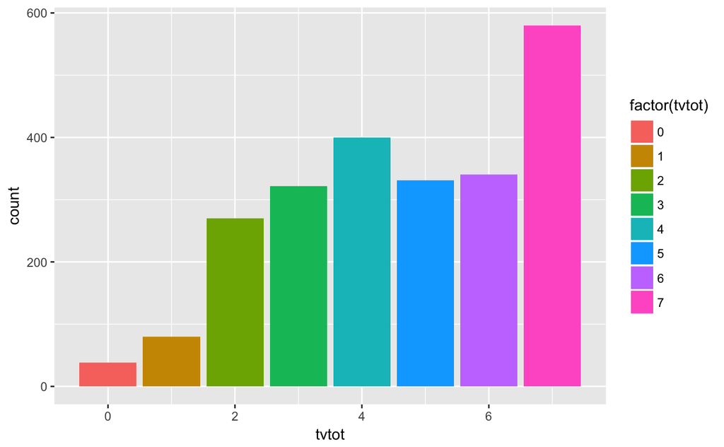

```r
p1 <- ggplot(ruweData) +
  geom_bar(aes(x = tvtot, fill = factor(tvtot)))
p1
```

Een andere variabele geeft het vertrouwen weer dat personen in anderen hebben. Ook deze kunnen we in een grafiek weergeven. Deze keer maken we onderscheid naar geslacht.

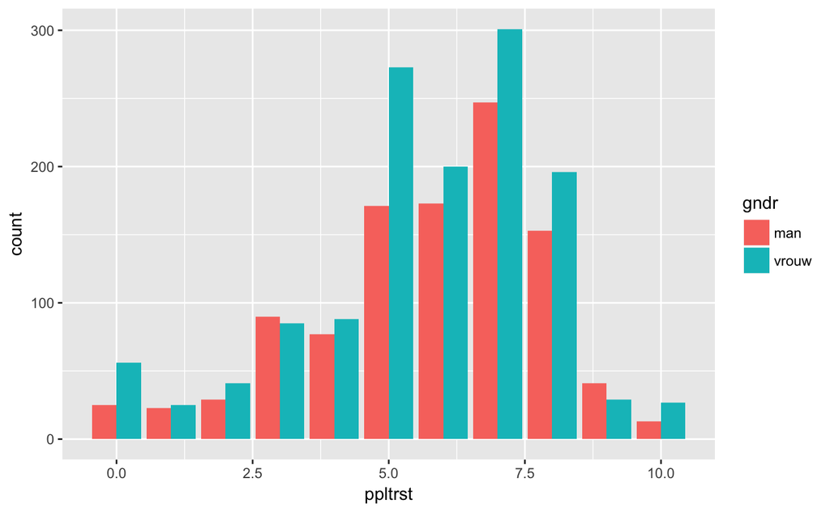

```r
p2 <- ggplot(ruweData) +
  geom_bar(aes(x = ppltrst, fill = gndr), position = position_dodge())
p2
```

We moeten hier voorzichtig zijn met het trekken van conclusies, want we hadden al opgemerkt dat er sowieso meer vrouwen hadden deelgenomen aan de survey dan mannen. Als vrouwen dezelfde verdeling van vertrouwen zouden hebben als mannen, zou iedere rechterkolom 27% hoger moeten zijn.

Daarom kunnen we beter eerst de relatieve verhoudingen uitrekenen en dan pas visualiseren.

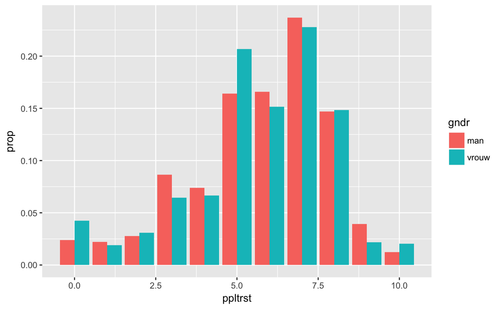

```r
cntTrstGndr <- count(ruweData, ppltrst, gndr)
grpByTrst <- cntTrstGndr %>%
  na.omit() %>%
  group_by(gndr) %>%
  mutate(prop = n / sum(n))
p3 <- ggplot(grpByTrst) +
  geom_col(aes(x = ppltrst, y = prop, fill = gndr), position = position_dodge())
p3
```

Er zijn geen opvallende verschillen. Wel als we naar andere variabelen kijken.

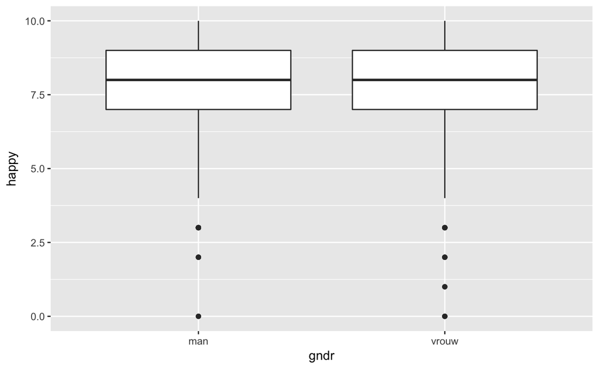

```r
# How happy are you?
ggplot(ruweData) +
  geom_boxplot(aes(x = gndr, y = happy))
```

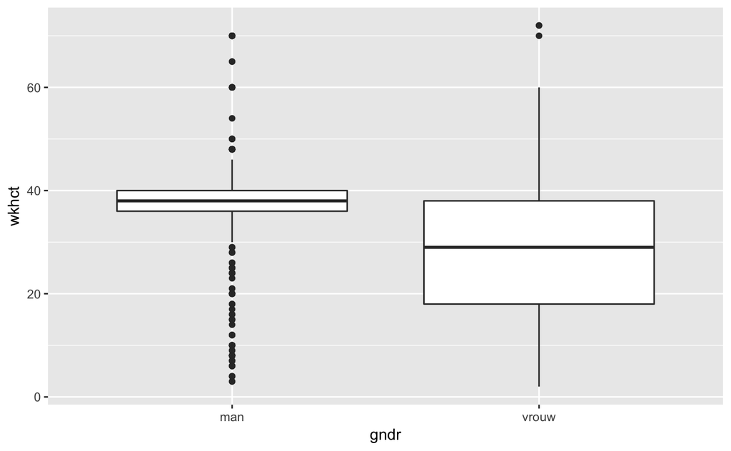

```r
# What are/were your total 'basic' or contracted hours each week (in your main job)?
ggplot(ruweData) +
  geom_boxplot(aes(x = gndr, y = wkhct))
```

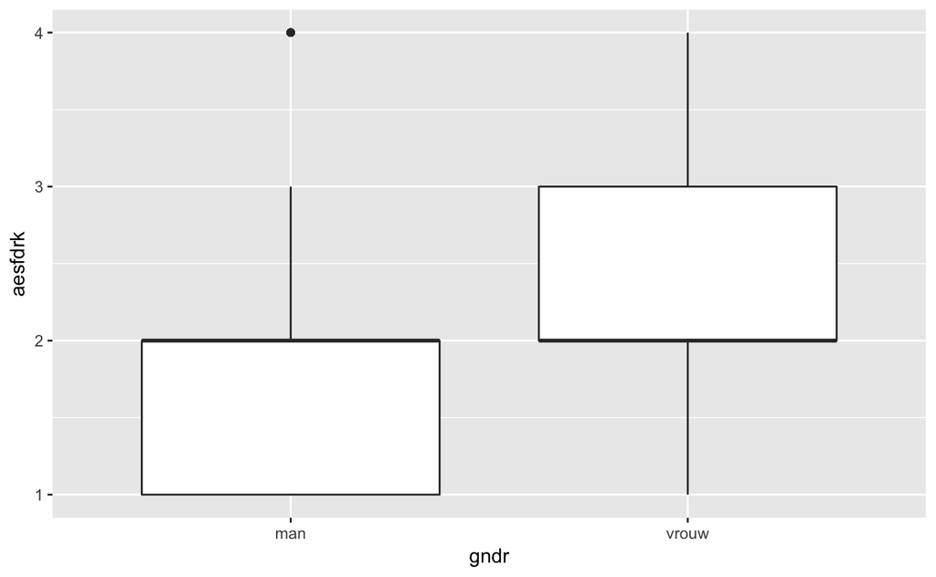

```r
# How safe do you - or would you - feel walking alone in this area after dark? 1=Very safe
ggplot(ruweData) +
  geom_boxplot(aes(x = gndr, y = aesfdrk))
```